# Lesson 3 R Activity

Rick Davila

4/25/2020

### Install packages

```r
knitr::opts_chunk$set(echo = TRUE)

library(e1071)
library("xlsx")
library(xtable)

rm(list = ls())
```

### Read in rocket propellant data

Copy and paste the following information to your completed Lesson 1 R Activity .R file. Read data from Excel spreadsheet using the read.xlsx() command

```r
# uncomment for laptop 1
ex2_1 <- read.xlsx("data-ex-2-1.xlsx",
                   sheetIndex = 1,
                   colIndex = c(2,3),
                   as.data.frame = TRUE,
                   header = TRUE)
```

### Rocket propellant data - table printout

```r
xtable(ex2_1)
```

| Shear.Strength..psi..y_i | Age.of.Propellant..weeks..x_i |
| --- | --- |
| 2158.70 | 15.50 |
| 1678.15 | 23.75 |
| 2316.00 | 8.00 |
| 2061.30 | 17.00 |
| 2207.50 | 5.50 |
| 1708.30 | 19.00 |
| 1784.70 | 24.00 |
| 2575.00 | 2.50 |
| 2357.90 | 7.50 |
| 2256.70 | 11.00 |

[output cut: 10 more lines]

### Data structure and dimensions of data

Output data structure and dimensions using the str() and dim() commands

```r
# output dataframe structure
str(ex2_1)
```

```
## 'data.frame':    20 obs. of  2 variables:
##  $ Shear.Strength..psi..y_i     : num  2159 1678 2316 2061 2208 ...
##  $ Age.of.Propellant..weeks..x_i: num  15.5 23.8 8 17 5.5 ...
```

```r
# dim of data 'matrix' (i.e., should be 20 rows by 2 columns)
dim(ex2_1)
```

```
## [1] 20  2
```

### Print out tabel using revised column names

```r
names(ex2_1) <- c("Shear_Strength", "Age")
attach(ex2_1)

#Printout revised table using new column names
xtable(ex2_1)
```

| Shear_Strength | Age |
| --- | --- |
| 2158.70 | 15.50 |
| 1678.15 | 23.75 |
| 2316.00 | 8.00 |
| 2061.30 | 17.00 |
| 2207.50 | 5.50 |
| 1708.30 | 19.00 |
| 1784.70 | 24.00 |
| 2575.00 | 2.50 |
| 2357.90 | 7.50 |
| 2256.70 | 11.00 |

[output cut: 10 more lines]

### Create scatter plot

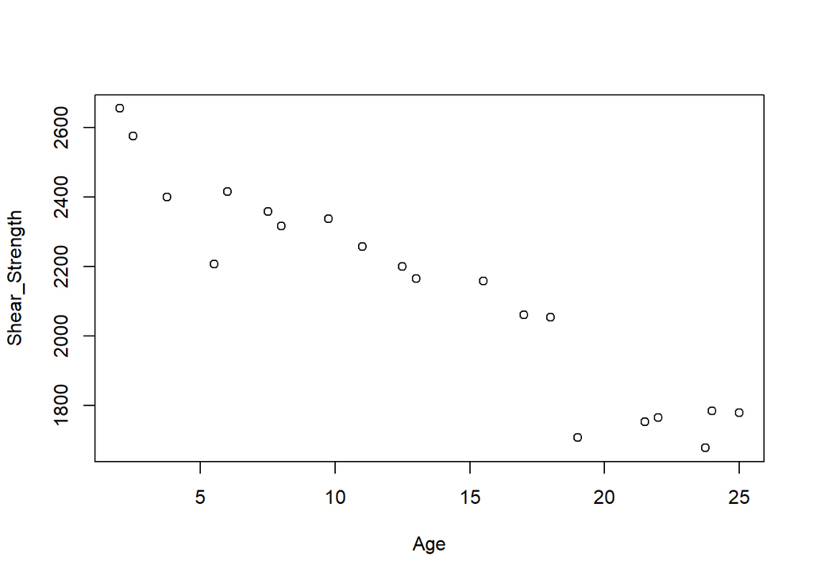

```r
# Create scatterplot using plot()
plot(Age, Shear_Strength)
```

### Create linear model “by hand”

First, perform intermediary calculations - Syy, Sxx, Sxy, x_bar, y_bar, num

```r
# num = length(Age)
num = length(Age)

Syy = sum(Shear_Strength^2) - (sum(Shear_Strength))^2/num
print(sprintf("Syy = %f",Syy))
```

```
## [1] "Syy = 1693737.601375"
```

```r
# From Eq. (2.9) in the e-book
Sxx = sum(Age^2) - (sum(Age))^2/num
print(sprintf("Sxx = %f",Sxx))
```

```
## [1] "Sxx = 1106.559375"
```

```r
# From Eq. (2.10) in the e-book
Sxy=sum(Age*Shear_Strength)-sum(Age)*sum(Shear_Strength)/num
print(sprintf("Sxy = %f",Sxy))
```

```
## [1] "Sxy = -41112.654375"
```

```r
#x_bar and y_bar ...
x_bar = sum(Age)/num
y_bar = sum(Shear_Strength)/num
print(sprintf("x_bar = %f and y_bar = %f",x_bar, y_bar))
```

```
## [1] "x_bar = 13.362500 and y_bar = 2131.357500"
```

### Determine estimates for slope and intercept

```r
# slope, from Eq. (2.11) in the e-book
beta_1 = Sxy/Sxx
print(sprintf("beta_1 = %f",beta_1))
```

```
## [1] "beta_1 = -37.153591"
```

```r
# intercept, from Eq. (2.6) in the e-book
beta_0 = y_bar - beta_1*x_bar
print(sprintf("beta_0 = %f",beta_0))
```

```
## [1] "beta_0 = 2627.822359"
```

```r
print('The Least Squares regression line by hand:')
```

```
## [1] "The Least Squares regression line by hand:"
```

```r
print(sprintf(" y_hat = %f + (%f)x",beta_0, beta_1))
```

```
## [1] " y_hat = 2627.822359 + (-37.153591)x"
```

The equation is
$$\hat{y} = (-37.1535909)x + (2627.822359)$$

### Output the model ‘by hand’

```r
# Output 'by hand' model by hand
y_hat = beta_0 + beta_1*Age
Results = data.frame(Shear_Strength, y_hat)
names(Results) <- c("Observed Values","Fitted Values")
xtable(Results)
```

| Observed Values | Fitted Values |
| --- | --- |
| 2158.70 | 2051.942 |
| 1678.15 | 1745.425 |
| 2316.00 | 2330.594 |
| 2061.30 | 1996.211 |
| 2207.50 | 2423.478 |
| 1708.30 | 1921.904 |
| 1784.70 | 1736.136 |
| 2575.00 | 2534.938 |
| 2357.90 | 2349.170 |
| 2256.70 | 2219.133 |

[output cut: 10 more lines]

### Create the linear model using lm() command and display using the summary() command

```r
# Create linear model using lm() command and display output using the summary() command
model=lm(Shear_Strength~Age)
summary(model)
```

Call: lm(formula = Shear_Strength ~ Age)

Residuals: Min 1Q Median 3Q Max -215.98 -50.68 28.74 66.61 106.76

Residual standard error: 96.11 on 18 degrees of freedom Multiple R-squared: 0.9018, Adjusted R-squared: 0.8964 F-statistic: 165.4 on 1 and 18 DF, p-value: 1.643e-10

### Example 2.2 (p.21-22)

Obtain ANOVA table elements (by hand) - SST, SS_Regression, SS_Residual

```r
SST = sum((Shear_Strength - y_bar)^2)
SS_Regression = sum((y_hat - y_bar)^2)
SS_Residual = sum((Shear_Strength - y_hat)^2)

print(sprintf("note, Syy = SST = %f and SS_Reg+SS_Res = %f",Syy, SS_Regression+SS_Residual))
```

```
## [1] "note, Syy = SST = 1693737.601375 and SS_Reg+SS_Res = 1693737.601375"
```

```r
# Define degrees of freedom (by hand)
# num = length(Age) - number of observations
df_SST = num - 1          # 20 - 1 = 19
df_SS_Regression = 1              # 1
df_SS_Residual = num - 2  # 20 - 2 = 18

# Obtain residual degrees of freedom automatically using df.residual()
dfresidual = df.residual(model)
print(sprintf("residual degrees of freedom using df.residals = %i",dfresidual))
```

```
## [1] "residual degrees of freedom using df.residals = 18"
```

```r
# Obtain estimated error variance (MS_Residual)
MS_Residual = SS_Residual/dfresidual
print(sprintf("sigma^2, estimated error variance = %f",MS_Residual))
```

```
## [1] "sigma^2, estimated error variance = 9236.381004"
```

```r
#Obtain ANOVA table using aov() command or anova() command and display output
print(summary(aov(model)))
```

```
##             Df  Sum Sq Mean Sq F value   Pr(>F)
## Age          1 1527483 1527483   165.4 1.64e-10 ***
## Residuals   18  166255    9236
## ---
## Signif. codes:  0 '***' 0.001 '**' 0.01 '*' 0.05 '.' 0.1 ' ' 1
```

```r
print(summary(anova(model)))
```

```
##        Df            Sum Sq           Mean Sq           F value
##  Min.   : 1.00   Min.   : 166255   Min.   :   9236   Min.   :165.4
##  1st Qu.: 5.25   1st Qu.: 506562   1st Qu.: 388798   1st Qu.:165.4
##  Median : 9.50   Median : 846869   Median : 768360   Median :165.4
##  Mean   : 9.50   Mean   : 846869   Mean   : 768360   Mean   :165.4
##  3rd Qu.:13.75   3rd Qu.:1187176   3rd Qu.:1147921   3rd Qu.:165.4
##  Max.   :18.00   Max.   :1527483   Max.   :1527483   Max.   :165.4
##                                                      NA's   :1
##      Pr(>F)
##  Min.   :0
##  1st Qu.:0
##  Median :0
##  Mean   :0
##  3rd Qu.:0
##  Max.   :0
##  NA's   :1
```

### Example 2.3 (p.25)

Test significance of slope parameter (by hand) using the qt() and pt() commands for critical value and p-value for the t-distribution

```r
se_beta1 = sqrt(MS_Residual/Sxx)
test_statistic = beta_1/se_beta1

# for alpha = 0.05
alpha = 0.05
tcritical_value = abs(qt(alpha/2.0, df = df_SS_Residual))
p_value = 2*pt(-abs(test_statistic), df = df_SS_Residual)
print(sprintf("test statistic = %f, critical value = %f and p-value = %e", test_statistic, tcritical_value, p_value))
```

```
## [1] "test statistic = -12.859889, critical value = 2.100922 and p-value = 1.643344e-10"
```

The absolute value of the test statistic is greater than the crtical value
$$12.8 > 2.1$$
and p value is
$$1.64 \times 10^{-10}$$
… there’s a linear relationship etween the shear strength and the age of the propellant

### Example 2.4 (p. 28)

Test for significance of Regression (F-test) at .01 significance level

1. By hand

```r
# By hand:
# F_o test statistic
siglevel = 0.01

F_o = (SS_Regression/df_SS_Regression)/(SS_Residual/df_SS_Residual)
print(sprintf("F_o test statistic = %f", F_o))
```

```
## [1] "F_o test statistic = 165.376758"
```

```r
Fcritical = qf(1-siglevel, df_SS_Regression, df_SS_Residual)
print(sprintf("F statistic = %f",Fcritical))
```

```
## [1] "F statistic = 8.285420"
```

```r
# as a check, from table A.4 in the e-book, F_(0.01,1,18) = 8.29
p_val = 1 - pf(F_o, df_SS_Regression, df_SS_Residual)
print(sprintf("F p value = %e",p_val))
```

```
## [1] "F p value = 1.643343e-10"
```

Since
$$F_0 = 165.36 > F_{(0.01,1,18)}$$
We can reject the null hypotheses, there’s a relationship between the shear strength and the age of the rocket propellant

2. Using aov and anova commands

Lesson 2 - Using aov and anova functions:

aov model output

```r
summary(aov(model))
```

```
##             Df  Sum Sq Mean Sq F value   Pr(>F)
## Age          1 1527483 1527483   165.4 1.64e-10 ***
## Residuals   18  166255    9236
## ---
## Signif. codes:  0 '***' 0.001 '**' 0.01 '*' 0.05 '.' 0.1 ' ' 1
```

anova model output

```r
summary(anova(model))
```

```
##        Df            Sum Sq           Mean Sq           F value
##  Min.   : 1.00   Min.   : 166255   Min.   :   9236   Min.   :165.4
##  1st Qu.: 5.25   1st Qu.: 506562   1st Qu.: 388798   1st Qu.:165.4
##  Median : 9.50   Median : 846869   Median : 768360   Median :165.4
##  Mean   : 9.50   Mean   : 846869   Mean   : 768360   Mean   :165.4
##  3rd Qu.:13.75   3rd Qu.:1187176   3rd Qu.:1147921   3rd Qu.:165.4
##  Max.   :18.00   Max.   :1527483   Max.   :1527483   Max.   :165.4
##                                                      NA's   :1
##      Pr(>F)
##  Min.   :0
##  1st Qu.:0
##  Median :0
##  Mean   :0
##  3rd Qu.:0
##  Max.   :0
##  NA's   :1
```

### Example 3 2.5 (p 30)

Construct a $95\%$ confidence interval (CI) for the slope parameter (by hand) The $100\left(1-\alpha\right)$ percent confidence interveral (CI) of the slope $\beta_1$ is given by
$$\hat{\beta}_1 - t_{\alpha/2,n-2}se(\hat{\beta}_1) \le \hat{\beta}_1 \le \hat{\beta}_1 + t_{\alpha/2,n-2}se(\hat{\beta}_1)$$
We construct a $95%$ CI on $\beta_1$ by using the standard error of $\hat{\beta}_1$ is $se(\hat{\beta}_1) = \sqrt{MS_{Res}/S_{xx}}$ and $t_{0.025,18} = 2.100922$

```r
# Example 2.5 (p. 30)
# Construct a 95% confidence interval for the slope parameter (by hand)

se_beta_1 = sqrt(MS_Residual/Sxx)
CIleft_wing = beta_1 - tcritical_value * se_beta_1
CIright_wing = beta_1 + tcritical_value * se_beta_1
```

The $95\%$ CI on the slope is
$$-37.1535909 - (2.100922)(2.8891065) \le \hat{\beta}_1 \le -37.1535909 + (2.100922)(2.8891065)$$
or

$$-43.2233786 \le \hat{\beta}_1 \le-31.0838033$$

check using the Confint command

```r
# Check using Confint command
confint(model, level = 0.95)
```

```
##                  2.5 %    97.5 %
## (Intercept) 2534.99540 2720.6493
## Age          -43.22338  -31.0838
```

Construct 95% C.I. for the point x0 = 13.3625

Consider finding a $95\%$ CI on $E(y|x_0)$. The CI per Eq. (2.43) in the e-book is
$$\hat{\mu}_{y|x_0} - t_{\alpha/2,n-2}\sqrt{MS_{Res}\left(\frac{1}{n} + \frac{(x_0-\bar{x})^2}{Sxx}\right)} \le E(y|x_0) \le \hat{\mu}_{y|x_0} + t_{\alpha/2,n-2}\sqrt{MS_{Res}\left(\frac{1}{n} + \frac{(x_0-\bar{x})^2}{Sxx}\right)}$$
for the Rocket Propellant data, we have
$$\hat{\mu}_{y|x_0} - (2.100922)\sqrt{9236.3810037\left(\frac{1}{20} + \frac{(x_0-13.3625)^2}{1106.559375}\right)} \le E(y|x_0) \le \hat{\mu}_{y|x_0} + (2.100922)\sqrt{9236.3810037\left(\frac{1}{20} + \frac{(x_0-13.3625)^2}{1106.559375}\right)}$$

For this case, $\hat{\mu}_{y|x_0=13.3625}$ is

```r
x0 = 13.3625
mu_hat_x0 = beta_1 * x0 + beta_0
mu_hat_x0
```

```
## [1] 2131.358
```

and the CI at $\hat{\mu}_{y|x_0=13.3625} = 2131.3575$ is

```r
Sqrt_quantity = sqrt(MS_Residual*(1/num + (x0 - x_bar)^2/Sxx))
CIx0_left_wing = mu_hat_x0 - tcritical_value * Sqrt_quantity
CIx0_right_wing = mu_hat_x0 + tcritical_value * Sqrt_quantity
CIx0_left_wing
```

```
## [1] 2086.209
```

```r
CIx0_right_wing
```

```
## [1] 2176.506
```

or
$$2086.2087367 \le E(y|x_0=13.3625) \le 2176.5062633$$

### Example 2.7 (p. 34-35)

Construct a $95\%$ prediction interval for $x_0 = 10 \text{ weeks}$

The $100(1 - \alpha)$ percent prediction interval on a future observation at $x_0$ is
$$\hat{y_0} - t_{\alpha/2,n-2}\sqrt{MS_{Res}\left(1+ \frac{1}{n} + \frac{(x_0-\bar{x})^2}{Sxx}\right)} \le y_o \le \hat{y_0} + t_{\alpha/2,n-2}\sqrt{MS_{Res}\left(1 + \frac{1}{n} + \frac{(x_0-\bar{x})^2}{Sxx}\right)}$$
for $x_0 = 10 \text{ weeks}$, $\hat{y_0}$ is

```r
x0 = 10
y_hat = beta_1 * x0 + beta_0
y_hat
```

```
## [1] 2256.286
```

$\hat{y_0} = 2256.2864496$

so, the interval becomes

$$2256.2864496 - (2.100922)\sqrt{9236.3810037\left(1+ \frac{1}{20} + \frac{(10-13.3625)^2}{1106.559375}\right)} \le y_0 \le 2256.2864496 + (2.100922)\sqrt{9236.3810037\left(1 + \frac{1}{20} + \frac{(10-13.3625)^2}{1106.559375}\right)}$$
which simplies to

```r
x0 = 10
Sqrt_quantity = sqrt(MS_Residual*(1 + 1/num + (x0 - x_bar)^2/Sxx))
PI_left_wing = y_hat - tcritical_value * Sqrt_quantity
PI_right_wing = y_hat + tcritical_value * Sqrt_quantity
PI_left_wing
```

```
## [1] 2048.385
```

```r
PI_right_wing
```

```
## [1] 2464.188
```

$$2048.3845936 \le y_0 \le 2464.1883055$$

Superimpose a $95\%$ prediction and confidence interval plots onto the scatterplot of data using predict(), plot(), lines() and order() commands.

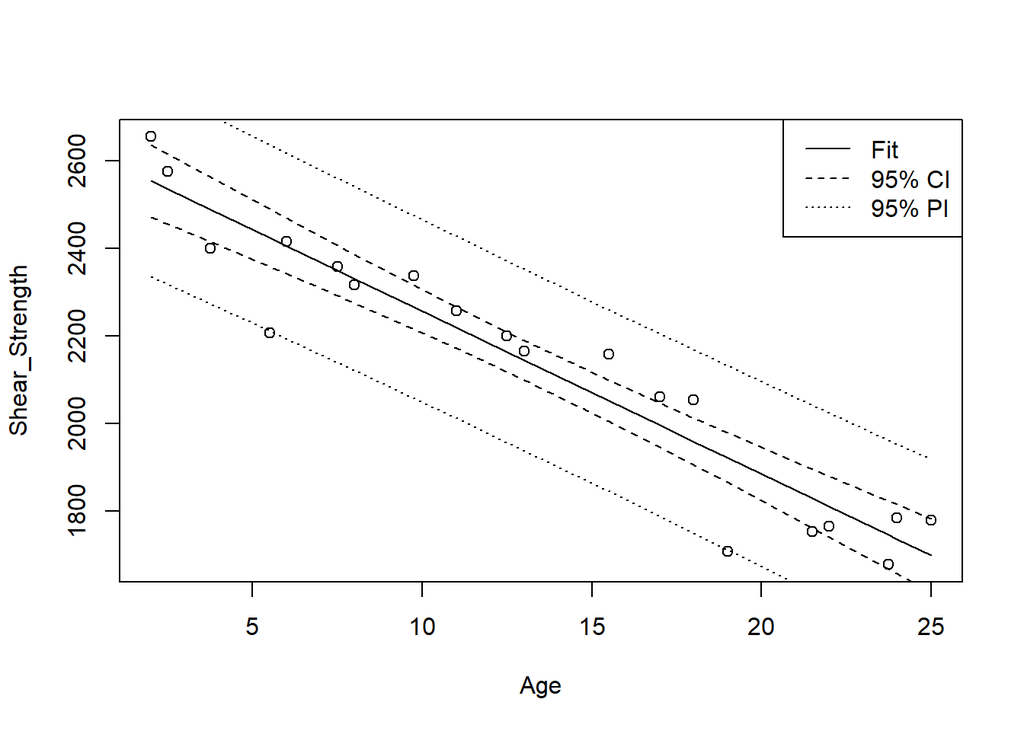

```r
# Obtain prediction interval lines automatically using predict()
# sorting data frame by Age ... recall from Lesson 1, attach(ex2_1) dataset

sorted_data <- ex2_1[order(Age),]
ci_band = predict(model, sorted_data, interval = "confidence", level = 0.95)

# Obtain confidence interval lines automatically using predict()
pi_band = predict(model, sorted_data, interval = "prediction", level = 0.95)

# Create scatterplot using plot()
plot(Age, Shear_Strength)

# Add line of predicted y_hat values using lines(). Be sure to use order() to ensure that x-values are in ascending (versus random) order

# sorted Age column, or x-values, in asending order are now , contained in sorted_data[,2]
y_hat = beta_1*sorted_data[,2] + beta_0
lines(sorted_data[,2], y_hat, lty = 1)

# Add prediction interval lines using lines() and order() commands
lines(sorted_data[,2], ci_band[,2], lty = 2)
lines(sorted_data[,2], ci_band[,3], lty = 2)


# Add confidence interval lines using lines() and order() commands
lines(sorted_data[,2], pi_band[,2], lty = 3)
lines(sorted_data[,2], pi_band[,3], lty = 3)

legend("topright", legend = c("Fit","95% CI","95% PI"), lty = c(1,2,3))
```